# ID : AI-0020

## Submission Date : 31/01/2018

# Abstract

<span style=" font-family: sans-serif; font-size: 1.07em";> **House Prices: Advanced Regression Techniques**

Kaggle has launched this competition with a dataset containing 79 explanatory variables, that describes almost every aspect of residential homes in Ames, Iowa. The target of this problem is to predict the house's sale price. We have performed a number of challenging tasks such as handling missing values and hyperparameter tuning while solving this problem. We have performed comparatively easier data visualization tasks such as correlational matrix or scatter plot, as it was the target of the competition. We have tried to provide a solution rigorous and robust enough so that the procedures followed here can be applied to similar problems in the future. Our complete solution consists of the following steps: Exploratory Data Analysis, Data Preprocessing, Feature Construction & Selection and, finally, Model building with fine-tuning of the Hyperparameters.</span>

# Purpose of project

The Kaggle Competition House Prices: Advanced Regression Techniques requires us to predict sale price of a house situated in Ames, Iowa. We have been provided with two datasets with various information regarding the houses like living area in square feet, house location, house and basement's condition, etc.

Necessary and Important tasks required for this project :

1. Wrangling, cleaning and preprocessing the data for modeling.
2. Detecting outliers
3. Fine tuning Hyper Parameters
4. Training different models and evaluating their performance.

# Our Approach

Solving Machine Learning Problems needs not only building Machine Learning Models but also rigorous data analysis. We need to be familiar with different features and their effect and influence on our target variable before building models. So keeping this in mind, we have catagorized our problem solving approach to following steps :

**Ch 1 : Dataset Loading in our environment**

Before everything else we first need to collect the data and load it into our working environment.

**Ch 2 : Exploratory Data Analysis**

In this Section we will completely and rigorously explore our dataset and watch and gain knowledge on different features as much as possible. Which features of a House actually dominates its Sale Price we will know here. We will also see which features are fluctuating too much or which tends to be correlated with other features.

**Ch 3 : Data Preprocessing**

Here we will handle missing cases. We will see are they really missing or this missing means anything else. We will fill up the missing values with our domain knowledge on features gained from previous step.

**Ch 4 : Feature Construction**

After we have dealt with missing cases, now we will see if it is possible to introduce some new features into our Dataset.

**Ch 5 : Feature Selection**

**Ch 6 : ANN Model Building**

1. Hyperparameter Tuning
2. Grid Search Method
3. Bayesian Optimization
4. Grid Search VS Bayesian Optimization
5. ANN model building with tuned Hyper Parameters

**Ch 7 : Ensembling**

Here we have ensembled and stacked multiple models together to build a more generalized model.

**Ch 8 : Residual Modeling**

Residual between Actual SalePrice and Predicted SalePrice can be used to build a residual model which will increase previous model's accuracy.

**Ch 9 : CNN Model Building**

We have build a Convolutional Neural Network Model here.

```python
import pandas as pd
import numpy as np
import seaborn as sns

from scipy.stats import norm
from sklearn.preprocessing import StandardScaler
from sklearn.metrics import mean_squared_error
from sklearn.metrics import r2_score
from scipy import stats
import warnings
import math
from collections import OrderedDict
import pickle
import random
from sklearn.svm import SVR
from sklearn.neighbors import KNeighborsRegressor
from sklearn.ensemble import RandomForestRegressor,ExtraTreesRegressor
from sklearn.linear_model import HuberRegressor
from sklearn.tree import DecisionTreeRegressor
from mlxtend.regressor import StackingRegressor
from sklearn.model_selection import GridSearchCV
from sklearn.neural_network import MLPRegressor
from sklearn.linear_model import HuberRegressor,LinearRegression
import time
from sklearn.externals import joblib
from sklearn import preprocessing

np.random.seed(42)


warnings.filterwarnings('ignore')
```

```python
from keras.models import Sequential
from keras.layers import Dense, Flatten, Dropout
from keras.layers.convolutional import Conv1D
from keras.optimizers import SGD
from keras.initializers import random_uniform
from keras.wrappers.scikit_learn import KerasRegressor

from math import sqrt
```

```python
from keras.layers.advanced_activations import LeakyReLU
```

```python
import matplotlib.pyplot as plt
plt.style.use(style='ggplot')
plt.rcParams['figure.figsize'] = (10, 6)
```

## Ch 1 : Dataset Loading in our environment

<span style="color: #455818; font-family: sans-serif; font-size: 1em";>

### Features list :

From Data Desciption provided by kaggle, Here we are providing definitions of some features:

**SalePrice**

the property's sale price in dollars. This is the target variable that we are trying to predict.

**MSSubClass**

The building class. It includes values like 20, 30, 40, 45 etc.

**MSZoning**

The general zoning classification. it indicates whether the building is in agricultural, commercial or in industrial zone.

**BldgType**

Type of dwelling,. For which type of family the building is suitable for : single family or two family.

**OverallQual**

Rates the overall material and finish of the house

**OverallCond**

Rates the overall condition of the house. rtaing value ranges from 1 to 10 where 1 stands for very poor quality and 10 stands fro very excellent quality.

**Street**

Type of road access to the property. Is the street paved or gravel ?

**Alley**

Type of alley access. Is there any type of alley which can be used to enter the property ? If there is , what is it's type ? Paved or Gravel ?

**LotShape**

General shape of property. Does it have regular shape or irregular shape ? If irregular , what is the extent fo irregularity ? Slightly , moderately ?

**LandContour**

Flatness of the property

**LotFrontage**

Linear feet of street connected to property

**YearBuilt**

Original construction date

**YearRemodAdd**

Remodel date (same as construction date if no remodeling or additions)

**RoofStyle**

Type of roof : Flat, Gable, Gabrel, Hip, Mansard or Shed

**Utilities**

Type of utilities available

**LotConfig**

Lot configuration

**LotArea**

Lot size in square feet

**HouseStyle**

Is the building 1 story , 2story or 1 and half story ?

**BsmtQual**

Indicates teh height of basement. Depending on height, there are 6 types of basement ( Excellent, Good, Typical, Fair, Poor and No Basement )

**BsmtCond**

Evaluates the general condition of the basement.

**TotalBsmtSF**

Total area of basement in square feet.

**GrLivArea**

Total living area above ground in square feet.

**GarageType**

Where is the garage ? Is it attached to home or in basement or detached from home ?

**PoolArea**

Pool area in square feet.

**WoodDeckSF**

Wood deck area in square feet.

</span></ol>

```python
train_df = pd.read_csv("train.csv")
train_df.rename(columns={'1stFlrSF':'FstFlrSF','2ndFlrSF':'SndFlrSF'}, inplace = True)

test_df = pd.read_csv("test.csv")
test_df.rename(columns={'1stFlrSF':'FstFlrSF','2ndFlrSF':'SndFlrSF'}, inplace = True)
```

```python
# lets see the features our dataset contains
train_df.columns
```

```
Index(['Id', 'MSSubClass', 'MSZoning', 'LotFrontage', 'LotArea', 'Street',
       'Alley', 'LotShape', 'LandContour', 'Utilities', 'LotConfig',
       'LandSlope', 'Neighborhood', 'Condition1', 'Condition2', 'BldgType',
       'HouseStyle', 'OverallQual', 'OverallCond', 'YearBuilt', 'YearRemodAdd',
       'RoofStyle', 'RoofMatl', 'Exterior1st', 'Exterior2nd', 'MasVnrType',
       'MasVnrArea', 'ExterQual', 'ExterCond', 'Foundation', 'BsmtQual',
       'BsmtCond', 'BsmtExposure', 'BsmtFinType1', 'BsmtFinSF1',
       'BsmtFinType2', 'BsmtFinSF2', 'BsmtUnfSF', 'TotalBsmtSF', 'Heating',
       'HeatingQC', 'CentralAir', 'Electrical', 'FstFlrSF', 'SndFlrSF',
       'LowQualFinSF', 'GrLivArea', 'BsmtFullBath', 'BsmtHalfBath', 'FullBath',
       'HalfBath', 'BedroomAbvGr', 'KitchenAbvGr', 'KitchenQual',
       'TotRmsAbvGrd', 'Functional', 'Fireplaces', 'FireplaceQu', 'GarageType',
       'GarageYrBlt', 'GarageFinish', 'GarageCars', 'GarageArea', 'GarageQual',
       'GarageCond', 'PavedDrive', 'WoodDeckSF', 'OpenPorchSF',
       'EnclosedPorch', '3SsnPorch', 'ScreenPorch', 'PoolArea', 'PoolQC',
       'Fence', 'MiscFeature', 'MiscVal', 'MoSold', 'YrSold', 'SaleType',
       'SaleCondition', 'SalePrice'],
      dtype='object')
```

## Ch 2 : Exploratory Data Analysis

### 2.1 Statistics Summary of Features

<span style="font-family: sans-serif; font-size: 1em";>

- From statistics summary of features, we can average value for Every features and this gives us the knowdlege of their value range.

</ul>

#### Our deduction on some features:

**LotFrontage**

Even though LotFrontage has a maximum value of 313 feet, 75% of data points have LotFrontage less than or equal 80 feet.

**YearBuilt**

50% of the houses have been built before or at 1973. 50% of the houses are quite old.

**MasVnrArea, WoodDeckSF**

50% houses have no Masonry veneer or wood deck.

**PoolArea**

Maximum Pool Area among houses of obeservations is 738 square feet but 75% of houses do not have any Pool.

```python
train_df.describe()
```

|  | Id | MSSubClass | LotFrontage | LotArea | OverallQual | OverallCond | YearBuilt | YearRemodAdd | MasVnrArea | BsmtFinSF1 | ... | WoodDeckSF | OpenPorchSF | EnclosedPorch | 3SsnPorch | ScreenPorch | PoolArea | MiscVal | MoSold | YrSold | SalePrice |
| --- | --- | --- | --- | --- | --- | --- | --- | --- | --- | --- | --- | --- | --- | --- | --- | --- | --- | --- | --- | --- | --- |
| count | 1460.000000 | 1460.000000 | 1201.000000 | 1460.000000 | 1460.000000 | 1460.000000 | 1460.000000 | 1460.000000 | 1452.000000 | 1460.000000 | ... | 1460.000000 | 1460.000000 | 1460.000000 | 1460.000000 | 1460.000000 | 1460.000000 | 1460.000000 | 1460.000000 | 1460.000000 | 1460.000000 |
| mean | 730.500000 | 56.897260 | 70.049958 | 10516.828082 | 6.099315 | 5.575342 | 1971.267808 | 1984.865753 | 103.685262 | 443.639726 | ... | 94.244521 | 46.660274 | 21.954110 | 3.409589 | 15.060959 | 2.758904 | 43.489041 | 6.321918 | 2007.815753 | 180921.195890 |
| std | 421.610009 | 42.300571 | 24.284752 | 9981.264932 | 1.382997 | 1.112799 | 30.202904 | 20.645407 | 181.066207 | 456.098091 | ... | 125.338794 | 66.256028 | 61.119149 | 29.317331 | 55.757415 | 40.177307 | 496.123024 | 2.703626 | 1.328095 | 79442.502883 |
| min | 1.000000 | 20.000000 | 21.000000 | 1300.000000 | 1.000000 | 1.000000 | 1872.000000 | 1950.000000 | 0.000000 | 0.000000 | ... | 0.000000 | 0.000000 | 0.000000 | 0.000000 | 0.000000 | 0.000000 | 0.000000 | 1.000000 | 2006.000000 | 34900.000000 |
| 25% | 365.750000 | 20.000000 | 59.000000 | 7553.500000 | 5.000000 | 5.000000 | 1954.000000 | 1967.000000 | 0.000000 | 0.000000 | ... | 0.000000 | 0.000000 | 0.000000 | 0.000000 | 0.000000 | 0.000000 | 0.000000 | 5.000000 | 2007.000000 | 129975.000000 |
| 50% | 730.500000 | 50.000000 | 69.000000 | 9478.500000 | 6.000000 | 5.000000 | 1973.000000 | 1994.000000 | 0.000000 | 383.500000 | ... | 0.000000 | 25.000000 | 0.000000 | 0.000000 | 0.000000 | 0.000000 | 0.000000 | 6.000000 | 2008.000000 | 163000.000000 |
| 75% | 1095.250000 | 70.000000 | 80.000000 | 11601.500000 | 7.000000 | 6.000000 | 2000.000000 | 2004.000000 | 166.000000 | 712.250000 | ... | 168.000000 | 68.000000 | 0.000000 | 0.000000 | 0.000000 | 0.000000 | 0.000000 | 8.000000 | 2009.000000 | 214000.000000 |
| max | 1460.000000 | 190.000000 | 313.000000 | 215245.000000 | 10.000000 | 9.000000 | 2010.000000 | 2010.000000 | 1600.000000 | 5644.000000 | ... | 857.000000 | 547.000000 | 552.000000 | 508.000000 | 480.000000 | 738.000000 | 15500.000000 | 12.000000 | 2010.000000 | 755000.000000 |

8 rows × 38 columns

### 2.2 Statistics Summary of Sale Price ( Target Variable )

<span style="font-family: sans-serif; font-size: 1em";>

- From statistics summary of Sale Price , we can see that behavior of Sale Price .

</ul>

#### Our deduction on target variable:

Average SalePrice is 180K.

Most of the houses have SalePrice between 130k and 214K.

```python
# lets see the behavior of our target variable
train_df['SalePrice'].describe()
```

```
count      1460.000000
mean     180921.195890
std       79442.502883
min       34900.000000
25%      129975.000000
50%      163000.000000
75%      214000.000000
max      755000.000000
Name: SalePrice, dtype: float64
```

### 2.3 Distribution of Sale Price ( Target Variable )

Distribution of SalePrice shows positive skewness.

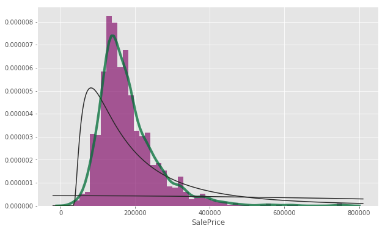

```python
#Lets see SalePrice's histogram
sns.set_color_codes("dark")
sns.distplot(train_df['SalePrice'],fit=stats.gilbrat,color='r', kde_kws={"color":"c","lw":4,"alpha":0.5});
sns.distplot(train_df['SalePrice'],fit=stats.gamma,color='m', kde_kws={"color":"g","lw":4,"alpha":0.5});
```

SalePrice's Distribution is showing positive skewness.

SalePrice's Distribution has some peakedness too.

As the distribution plot is showing skewness, we can observe the mathematical amount of this skewness

```python
print("Skewness: ", train_df['SalePrice'].skew())
print("Kurtosis: ", train_df['SalePrice'].kurt())
```

```
Skewness:  1.8828757597682129
Kurtosis:  6.536281860064529
```

### 2.4 List of numerical and categorical variables

We need to find out which features are numerical and which are categorical as our model won,t be able to deal with categorical variables.

We have seen that following features and many others are numerical features.

- OverallQual
- OverallCond
- TotalBsmtSF
- FstFlrSF etc.

We have seen that following features and many others are categorical features.

- HeatingQC
- BsmtQual
- PoolQC
- GarageFin etc.

```python
# lets sort out catagorical and numerical features

cols = train_df.columns
num_cols = list(train_df._get_numeric_data().columns.values)

# lets remove ID as it is not a feature actually
num_cols.remove('Id')
num_cols.remove('SalePrice')
print('''
              ......Numerical Variables.......
''')
print("{:<12} {:<10} {:<2}\n".format('Var name', 'Mean', 'Std'))

for var in num_cols:
    print("{:<12} {:<10} {:<2}\n".format(var, round(train_df[var].mean(),3), round(train_df[var].std(),3)))
```

```
              ......Numerical Variables.......

Var name     Mean       Std

MSSubClass   56.897     42.301

LotFrontage  70.05      24.285

LotArea      10516.828  9981.265

OverallQual  6.099      1.383

OverallCond  5.575      1.113

YearBuilt    1971.268   30.203

YearRemodAdd 1984.866   20.645

MasVnrArea   103.685    181.066

BsmtFinSF1   443.64     456.098

BsmtFinSF2   46.549     161.319

BsmtUnfSF    567.24     441.867

TotalBsmtSF  1057.429   438.705

FstFlrSF     1162.627   386.588

SndFlrSF     346.992    436.528

LowQualFinSF 5.845      48.623

GrLivArea    1515.464   525.48

BsmtFullBath 0.425      0.519

BsmtHalfBath 0.058      0.239

```

[output cut: 20 more lines]

```
OpenPorchSF  46.66      66.256

EnclosedPorch 21.954     61.119

3SsnPorch    3.41       29.317

ScreenPorch  15.061     55.757

PoolArea     2.759      40.177

MiscVal      43.489     496.123

MoSold       6.322      2.704

YrSold       2007.816   1.328
```

```python
cat_cols = list(set(cols) - set(num_cols))

# lets remove ID as it is not a feature actually
cat_cols.remove('Id')
cat_cols.remove('SalePrice')
print('''
              ......Categorical Variables.......
''')
train_df[cat_cols].describe()
```

```
              ......Categorical Variables.......
```

|  | BsmtFinType1 | Heating | BldgType | Functional | GarageFinish | KitchenQual | ExterQual | LotShape | Exterior2nd | HeatingQC | ... | BsmtQual | HouseStyle | Exterior1st | MSZoning | BsmtFinType2 | Condition2 | RoofMatl | CentralAir | FireplaceQu | SaleCondition |
| --- | --- | --- | --- | --- | --- | --- | --- | --- | --- | --- | --- | --- | --- | --- | --- | --- | --- | --- | --- | --- | --- |
| count | 1423 | 1460 | 1460 | 1460 | 1379 | 1460 | 1460 | 1460 | 1460 | 1460 | ... | 1423 | 1460 | 1460 | 1460 | 1422 | 1460 | 1460 | 1460 | 770 | 1460 |
| unique | 6 | 6 | 5 | 7 | 3 | 4 | 4 | 4 | 16 | 5 | ... | 4 | 8 | 15 | 5 | 6 | 8 | 8 | 2 | 5 | 6 |
| top | Unf | GasA | 1Fam | Typ | Unf | TA | TA | Reg | VinylSd | Ex | ... | TA | 1Story | VinylSd | RL | Unf | Norm | CompShg | Y | Gd | Normal |
| freq | 430 | 1428 | 1220 | 1360 | 605 | 735 | 906 | 925 | 504 | 741 | ... | 649 | 726 | 515 | 1151 | 1256 | 1445 | 1434 | 1365 | 380 | 1198 |

4 rows × 43 columns

### 2.5 Dependence on Numerical Features

#### Scatter plot

We have ploted scatter plot for features against target variable SalePrice to see the effect of features on SalePrice.

While plotting, for every different features scatter plot is plotted seperately.

While creating scatter plot of Feature VS SalePrice scatter plot, we have plotted feature value along X axis and SalePrice along Y axis.

Linear relation means that one variable increases, the other also increases. From Our observations following Features shows strong relationship with Sale Price :

- OverallQual
- GrLivArea
- GarageArea
- TotalBsmtSF
- YearBuilt
- LotFrontage
- LotArea
- MasVnrArea
- BsmtFinSF1
- TotalBsmtSF
- FstFlrSF

#### Why scatter plot ?

We can only see correlation matrix to detect the effect of different features on target variable SalePrice. However, we have plotted scatter plot for several reasons:

Correlation matrix only capture Linear relation ship between features and target variable. If any feature has ** non-linear ** relationship with target variable Correlation Matrix would not be able to capture that.

From our observation we can say that **TotalBsmtSF** has more **exponential** relation than **linear ** relation with SalePrice.

Previous Statement applies for LotArea too. **LotArea** has more **exponential** relation than **linear ** relation with SalePrice.

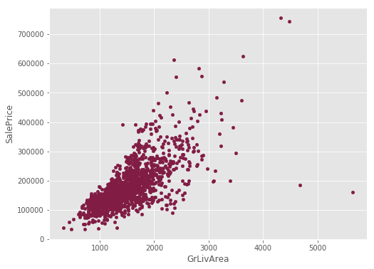

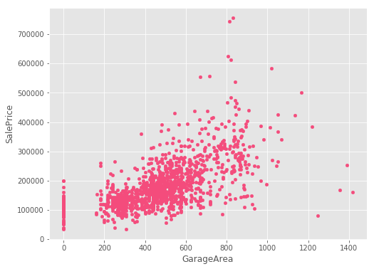

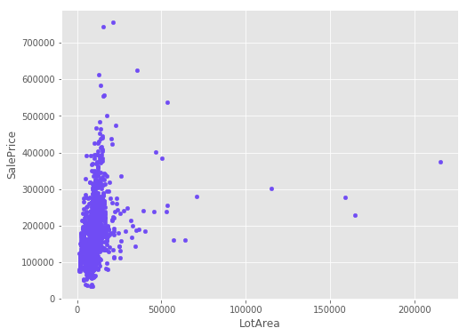

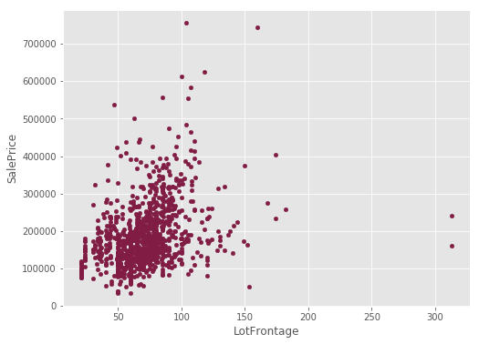

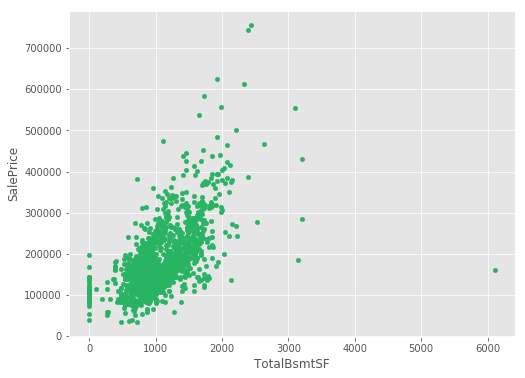

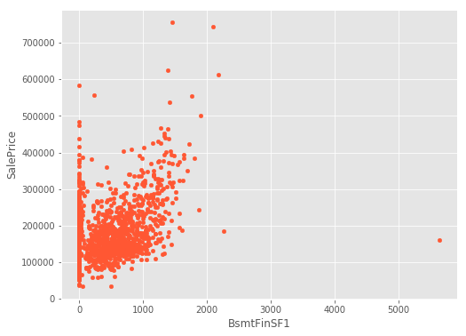

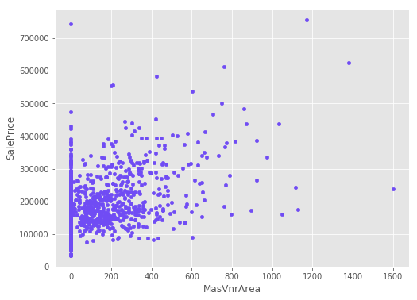

```python
### ............. Lets see some Data visualization..................
plt.rcParams['figure.figsize'] = (8, 6)
sns.set_color_codes('muted')
colors = ['#CD5C5C','#DC7633','#28B463','#F44C7C','#704CF4','#6B811C','#811C44','#FF5733']
for x in ['GrLivArea','GarageArea', 'LotArea', 'LotFrontage', 'TotalBsmtSF', 'BsmtFinSF1','MasVnrArea']:
    plot = train_df.plot(kind="scatter", x=x, y="SalePrice",color=colors[np.random.randint(0,8)])
```

#### Box plot

Boxplot is a method for graphically depicting groups of numerical data through their Interquartile range. Boxplot have been drawn for features :

1. OverallQual
2. GarageCars
3. FullBath
4. TotRmsAbvGrd
5. YeraBuilt

SalePrice drops as the YearBuilt moves toward left side. Actually It means SalePrice drops as the House seems older.

SalePrice increases with increase in OverallQual. It means Houses with good quality ranking have higher SalePrice.

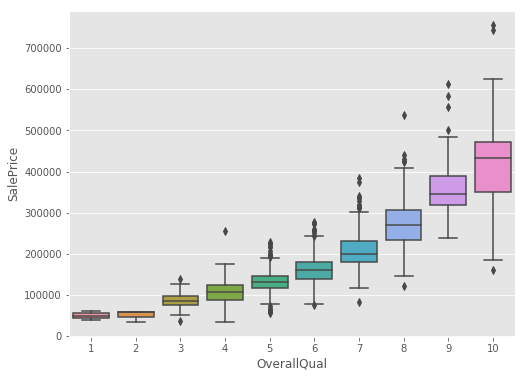

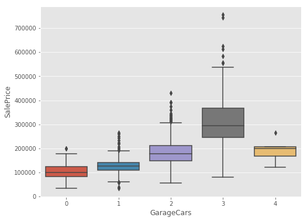

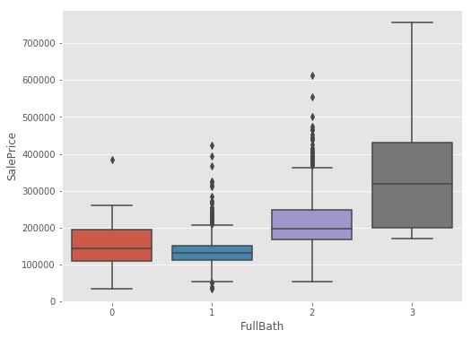

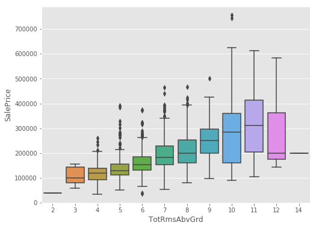

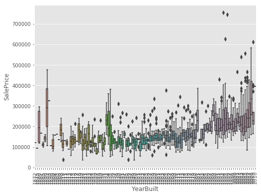

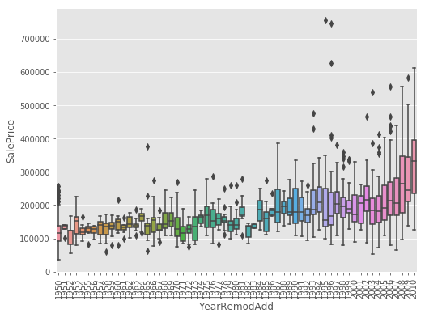

```python
## We will only see boxplots of highly influencial variables

influencial_cols = ['OverallQual', 'GarageCars', 'FullBath', 'TotRmsAbvGrd', 'YearBuilt',
       'YearRemodAdd']


for var in influencial_cols:
    data = pd.concat([train_df['SalePrice'], train_df[var]], axis=1)
    sns.boxplot(x=var,y='SalePrice', data=data);
    if var in ['YearBuilt','YearRemodAdd']:
        plt.xticks(rotation=90);
    plt.show();
```

#### Strip plot

We have plotted Strip plot for Neighborhood which is a categorical variable/feature. Strip plot is just like scatter plots we have drawn before . The only difference is that ordering along horizontal axis is arbitary. Here we have used alphabetical ordering.

From Strip plot it is evident that different neighborhood has different Sale Price and there is good amount of variation in Sale Price among neighborhoods.

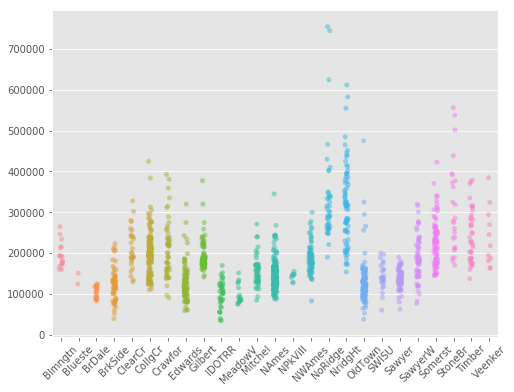

```python
sns.stripplot(x = train_df.Neighborhood.values, y = train_df.SalePrice.values,
              order = np.sort(train_df.Neighborhood.unique()),
              jitter=0.1, alpha=0.5)

plt.xticks(rotation=45)
```

#### Point plot

```python
Neighborhood_meanSalePrice = train_df.groupby('Neighborhood')['SalePrice'].mean()

Neighborhood_meanSalePrice = Neighborhood_meanSalePrice.sort_values()
```

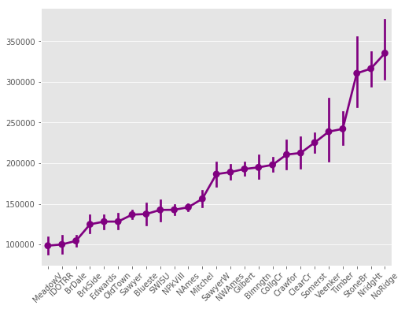

```python
sns.pointplot(x = train_df.Neighborhood.values, y = train_df.SalePrice.values,
              order = Neighborhood_meanSalePrice.index,color='purple')

plt.xticks(rotation=45)
```

### 2.6 Correlation Matrix

We have drawn two correlational matrix.

- First One show correlation betweeen every pair of Features including Sale Price
- SEcond one shows strongly related Features wth Sale Price in a Descending order

From Correlational Matrix following Features shows strong relationship with Sale Price :

- OverallQual
- GrLivArea
- GarageArea
- GarageCars
- TotalBsmtSF
- FstFlrSF
- FullBath
- YearBuilt

</ul>

This varifies our observation from previous steps.

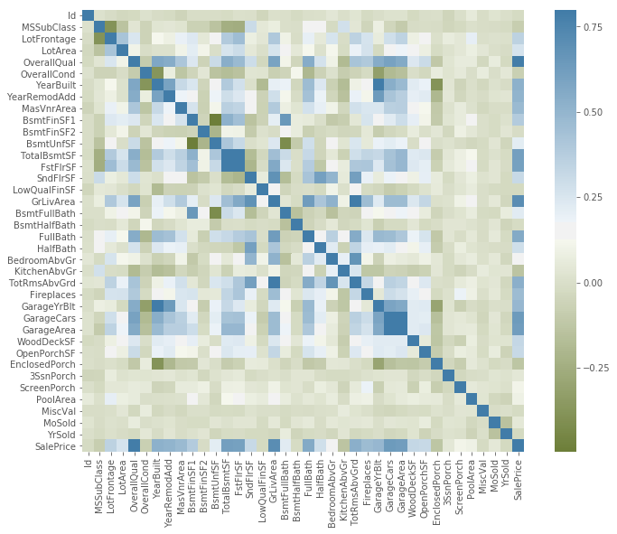

```python
#correlation matrix
corr_mat = train_df.corr()
f, ax = plt.subplots(figsize=(12, 9))
sns.heatmap(corr_mat, vmax=.8, square=True,cmap=sns.diverging_palette(100, 240,as_cmap=True));
```

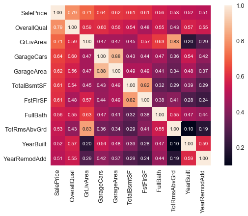

```python
#saleprice correlation matrix
k = 11
cols_k = corr_mat.nlargest(k, 'SalePrice')['SalePrice'].index
cm = np.corrcoef(train_df[cols_k].values.T)
sns.set(font_scale=1.25)
sns.heatmap(cm, cbar=True, annot=True, square=True, fmt='.2f', annot_kws={'size': 10}, yticklabels=cols_k.values, xticklabels=cols_k.values);
```

#### Pair plot

<span style=" font-family: sans-serif; font-size: 1.05em";> We have drawn pair plot for some highly influencial features to see their pair wise relation.</span>

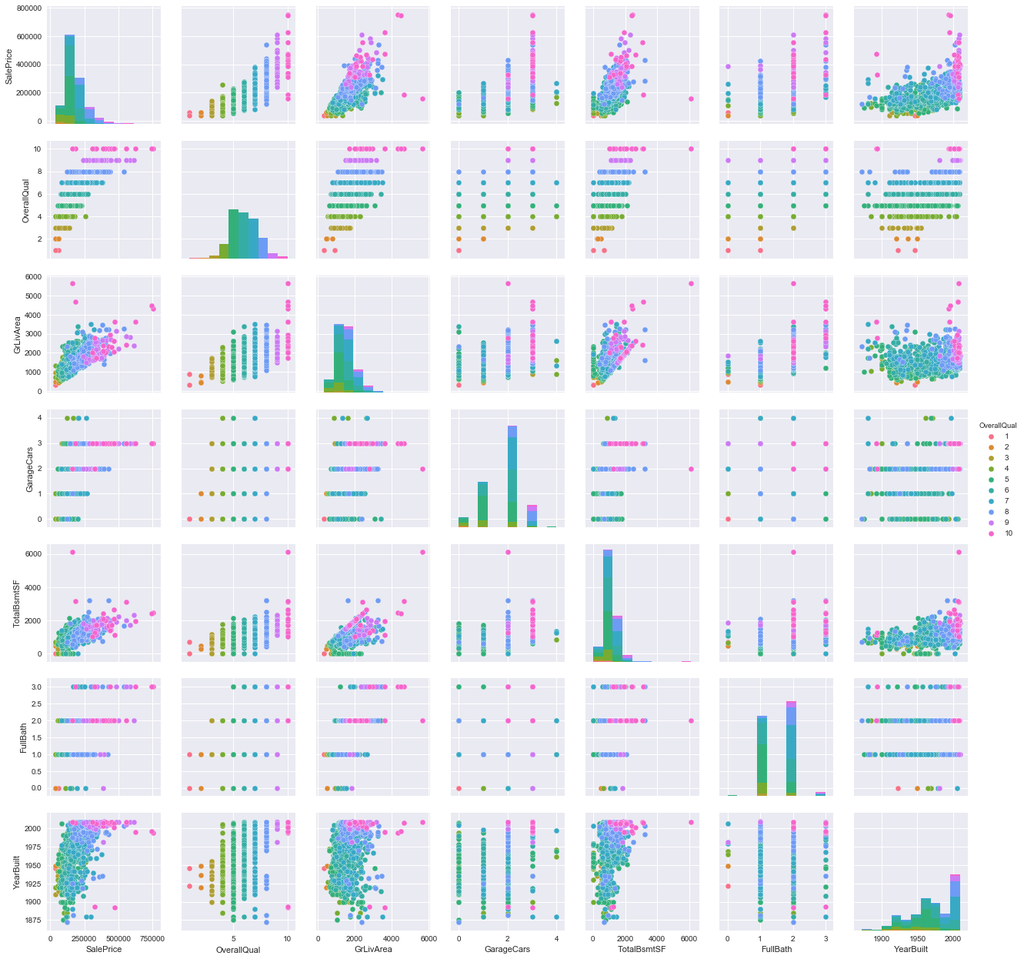

```python
#pairplot
sns.set()
cols = ['SalePrice', 'OverallQual', 'GrLivArea', 'GarageCars', 'TotalBsmtSF', 'FullBath', 'YearBuilt']
sns.pairplot(train_df[cols], size = 2.5, hue='OverallQual')
plt.show();
```

### 2.7 Principle Component Analysis

Principal component analysis (PCA) is a technique used to emphasize variation and bring out strong patterns in a dataset. It's often used to make data easy to explore and visualize. It's common technique to reduce dimension which makes it easy to visualize higher dimension data points in lower 2D/3D co-ordinate system.

After plotting datapoints using 3 principle component, we could not find any conspicuous patterns in data.

```python
from sklearn.decomposition import PCA
from mpl_toolkits.mplot3d import Axes3D
```

```python
# Keep the SalePrice column appart as it is our target variable

df = train_df.drop('SalePrice', axis=1)
X = df[influencial_cols].values

# Run The PCA
pca = PCA(n_components=6)
pca.fit(X)

# Store results of PCA in a data frame
columns = ['PCA%i' % i for i in range(6)]
result_df=pd.DataFrame(pca.transform(X), columns=columns, index=df.index)
my_color = result_df['PCA0']
```

```
PCA(copy=True, iterated_power='auto', n_components=6, random_state=None,
  svd_solver='auto', tol=0.0, whiten=False)
```

```python
pca_variance_ratio = pca.explained_variance_ratio_
```

```python
print('{:<5}  {:<5}\n'.format('PC', 'Variance ratio'))
for i in range(len(pca_variance_ratio)):
    pc = 'PC%i'%i
    print('{:<5}  {:<5}'.format(pc,round(pca_variance_ratio[i],5)))
```

```
PC     Variance ratio

PC0    0.82794
PC1    0.16886
PC2    0.00224
PC3    0.00064
PC4    0.00022
PC5    0.00011
```

#### Scatter plot for 3 Principle Components

```python
%%capture
# We are going to do 20 plots, for 20 different angles

for angle in range(70,210,2):
    # Plot initialisation
    fig = plt.figure()
    ax = fig.gca( projection='3d')
    ax.scatter(result_df['PCA0'], result_df['PCA1'], result_df['PCA2'],c=my_color, cmap="Set1_r", s=60)

    # axis lines through space:
    xAxisLine = ((min(result_df['PCA0']), max(result_df['PCA0'])), (0, 0), (0,0))
    ax.plot(xAxisLine[0], xAxisLine[1], xAxisLine[2], 'm')
    yAxisLine = ((0, 0), (min(result_df['PCA1']), max(result_df['PCA1'])), (0,0))
    ax.plot(yAxisLine[0], yAxisLine[1], yAxisLine[2], 'g')
    zAxisLine = ((0, 0), (0,0), (min(result_df['PCA2']), max(result_df['PCA2'])))
    ax.plot(zAxisLine[0], zAxisLine[1], zAxisLine[2], 'b')

    # label the axes
    ax.set_xlabel("PC1")
    ax.set_ylabel("PC2")
    ax.set_zlabel("PC3")
    ax.set_title("PCA on the House price data set")

    # Set the angle of the camera
    ax.view_init(30,angle)

    # Save it
    filename='pca_capture'+str(angle)+'.png'
    plt.savefig(filename, dpi=96);
    plt.gca();
```

```python
import IPython.display as IPdisplay

IPdisplay.Image(url='PCA.gif')
```

[figure not shown]

### 2.8 Linear Discriminant Analysis

Linear Discriminant Analysis (LDA) is most commonly used as dimensionality reduction technique in the pre-processing step. The goal is to project a dataset onto a lower-dimensional space and find patterns in data.

LDA just like PCA analysis shows the Data variance along different axis but using Clustering appproach.

We could not find any conspicuous patterns in data after LDA.

According to our analysis :

- 1st LDA axis alone covers around 66% of Data Variance
- To cover around 90% of Data Variance, we need around 4-5 LDA Axises.

```python
from sklearn.discriminant_analysis import LinearDiscriminantAnalysis
```

```python
y = train_df['SalePrice']
# Run The LDA
lda = LinearDiscriminantAnalysis(n_components=6)
lda.fit(X,y)

# Store results of PCA in a data frame
columns = ['LDA%i' % i for i in range(6)]
result_df=pd.DataFrame(lda.transform(X), columns=columns, index=df.index)
my_color = result_df['LDA0']
```

```
LinearDiscriminantAnalysis(n_components=6, priors=None, shrinkage=None,
              solver='svd', store_covariance=False, tol=0.0001)
```

```python
lda_variance_ratio = lda.explained_variance_ratio_
```

```python
print('{:<5}  {:<5}\n'.format('LDA', 'Variance ratio'))
for i in range(len(pca_variance_ratio)):
    pc = 'LD%i'%i
    print('{:<5}  {:<5}'.format(pc,round(lda_variance_ratio[i],5)))
```

```
LDA    Variance ratio

LD0    0.65565
LD1    0.09045
LD2    0.07605
LD3    0.06719
LD4    0.05758
LD5    0.05306
```

#### Scatter plot for 3 LDA Components

```python
%%capture
# We are going to do 20 plots, for 20 different angles

for angle in range(70,210,2):
    # Plot initialisation
    fig = plt.figure()
    ax = fig.gca( projection='3d')
    ax.scatter(result_df['LDA0'], result_df['LDA1'], result_df['LDA2'],c=my_color, cmap="Set1_r", s=60)

    # axis lines through space:
    xAxisLine = ((min(result_df['LDA0']), max(result_df['LDA0'])), (0, 0), (0,0))
    ax.plot(xAxisLine[0], xAxisLine[1], xAxisLine[2], 'm')
    yAxisLine = ((0, 0), (min(result_df['LDA1']), max(result_df['LDA1'])), (0,0))
    ax.plot(yAxisLine[0], yAxisLine[1], yAxisLine[2], 'g')
    zAxisLine = ((0, 0), (0,0), (min(result_df['LDA2']), max(result_df['LDA2'])))
    ax.plot(zAxisLine[0], zAxisLine[1], zAxisLine[2], 'b')

    # label the axes
    ax.set_xlabel("LD1")
    ax.set_ylabel("LD2")
    ax.set_zlabel("LD3")
    ax.set_title("LDA on the House price data set")

    # Set the angle of the camera
    ax.view_init(30,angle)

    # Save it
    filename='LDA_capture'+str(angle)+'.png'
    plt.savefig(filename, dpi=96);
    plt.gca();
```

```python
IPdisplay.Image(url='LDA.gif')
```

[figure not shown]

## Ch 3 : Data Preprocessing

### 3.1 Handling Missing values

- Among Data Preprocessing steps our first task is to handle missing values. We have counted which Features have missing values and what percentage of missing values.
- There are some Features who have more than 15% missing values. Although many prefers to delete Features which have more than 15% missing values, we have not deleted them. Rather we have dealt with them statistiaclly and filled up them with reasonable values
- We have done previous step on both Train and Test Dataset.

```python
n_train = train_df.shape[0]
n_test = test_df.shape[0]

train_test = train_df.append(test_df, ignore_index=True)
train_test['SalePrice'].fillna(0, inplace = True)
```

[output not shown]

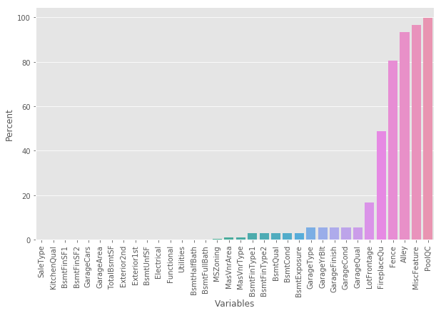

```python
miss_df = pd.DataFrame()
miss_df['Total'] = train_test.isnull().sum()
miss_df['Percent'] = (miss_df['Total'] / len(train_test)) * 100
miss_df = miss_df[miss_df['Percent'] > 0]
miss_df['Variables'] = miss_df.index
miss_df.sort_values(by='Percent', inplace=True)
print('Columns containing missing values :\n')
print(miss_df.drop('Variables', axis=1))
sns.barplot(x='Variables', y='Percent', data=miss_df)
plt.xticks(rotation=90);
```

[output not shown]

#### Lets Handle Features which contains missing values one by one :

#### PoolQC

PoolQC has a high percenatge of missing values. We can assume ,Missing values in PoolQC means that house does not have a Pool. That's why it's Pool quality is not available.

Remaining missing values of PoolQC now can be replaced with a new value 'NA' which means Not Available.

```python
train_test[(train_test['PoolQC'].isnull()) & (train_test['PoolArea'] > 0)][['PoolQC','PoolArea']]
```

|  | PoolQC | PoolArea |
| --- | --- | --- |
| 2420 | NaN | 368 |
| 2503 | NaN | 444 |
| 2599 | NaN | 561 |

```python
train_test.groupby('PoolQC')['PoolArea'].mean()
```

```
PoolQC
Ex    359.75
Fa    583.50
Gd    648.50
Name: PoolArea, dtype: float64
```

```python
train_test.loc[2420,'PoolQC'] = 'Ex'
train_test.loc[2503,'PoolQC'] = 'Ex'
train_test.loc[2599,'PoolQC'] = 'Fa'
```

```python
train_test['PoolQC'].fillna('NA', inplace= True)
```

#### GarageYrBlt

GarageYrBlt denotes the year the gaarge was built.We can assume that garage was built at the same time the house was built and this assumption seems reasonable.

To verify our assumption we can check whether GarageYrBlt and YearBuilt are same or not.

Out of 2919 houses, 2216 houses have same value for GarageYrBlt and YearBuilt. We can now confirm that our assumption is almost correct.

we will fill up the missing values of GarageYrBlt with the value of YearBuilt.

```python
print('Total house :', train_test.shape[0])
print('GarageYrBlt and YearBuilt same for :', end=' ')
print(sum(train_test['GarageYrBlt'] == train_test['YearBuilt']))
```

```
Total house : 2919
GarageYrBlt and YearBuilt same for : 2216
```

```python
train_test.loc[train_test['GarageYrBlt'].isnull(),'GarageYrBlt'] = \
train_test.loc[train_test['GarageYrBlt'].isnull(),'YearBuilt']
```

#### GarageArea and GarageCars

If any house does not have value for these two variables, we can assume that that house does not have a Garage.

In that case we can replace missing values of these variables with zero(0).

```python
for col in ('GarageArea', 'GarageCars'):
    train_test[col].fillna(0, inplace = True)
```

#### GarageQual, GarageFinish, GarageCond and GarageType

If any house does not have value for these variables, we can search for their value of GarageArea and GarageCars.

After anlyzing data we can see that the houses whcih have missing value for these variables have zero(0) value in GarageArea or simple they don't hava Garage.

That's why we have replaced missing values of these variables 'NA' which means Not Available.

```python
for col in ['GarageQual', 'GarageFinish', 'GarageCond', 'GarageType' ]:
    train_test[col].fillna('NA',inplace= True)
```

#### BsmtFinSF1, BsmtFinSF2, BsmtUnfSF, TotalBsmtSF, BsmtFullBath and BsmtHalfBath

Houses which have missing values for these variables means they don't have basement.

We can replace the missing values with zero(0).

```python
for col in ('BsmtFinSF1', 'BsmtFinSF2', 'BsmtUnfSF','TotalBsmtSF', 'BsmtFullBath', 'BsmtHalfBath'):
    train_test[col].fillna(0, inplace=True)
```

#### BsmtQual, BsmtCond, BsmtExposure, BsmtFinType1 and BsmtFinType2

Houses which have missing values for these variables means they don't have basement.

We can replace the missing values with 'No' which means no basement..

```python
for col in ('BsmtQual', 'BsmtCond', 'BsmtExposure', 'BsmtFinType1', 'BsmtFinType2'):
    train_test[col].fillna('No', inplace=True)
```

#### Exterior1st and Exterior2nd

```python
for col in ['Exterior1st', 'Exterior2nd']:
    train_test[col].fillna(train_test[col].mode()[0], inplace=True)
```

#### KitchenQual, Electrical and Utilities

Missing values in KitchenQual and Electrical will be replaced with most frequent values.

Utilities variable will be dropped from full dataset(both test and train datasets)

```python
train_test['KitchenQual'].fillna(train_test['KitchenQual'].mode()[0], inplace = True)
train_test['Electrical'].fillna(train_test['Electrical'].mode()[0], inplace = True)

train_test.drop(['Utilities'], axis=1, inplace = True)
```

#### SaleType and Functional

For SaleType, we will replace missing values with most frequent value 'WD'.

For Functinal, we will replace missing values with most frequent vale 'Typ'.

```python
train_test['SaleType'].fillna('WD', inplace=True)
```

```python
train_test['Functional'].fillna('Typ', inplace=True)
```

#### LotFrontage

We can assume that a house will have similar amount of frontage like anyother houses in its neighborhood.

That's why we will group dataset by neighborhood and replace missing value by the median of all the houses in same neighborhood.

```python
train_test["LotFrontage"] = train_test.groupby("Neighborhood")["LotFrontage"].transform(
    lambda x: x.fillna(x.median()))
```

#### MSZoning

We have grouped dataset by MSSubclass and find out most frequent MSZoning for every unique value of MSSubclass

For missing values of MSZoning, we have find out MSSubclass of that house and replace MSZoning with most frequent MSzoning of that MSSubclass.

```python
train_test[train_test['MSZoning'].isnull()][['MSZoning','MSSubClass']]
```

|  | MSZoning | MSSubClass |
| --- | --- | --- |
| 1915 | NaN | 30 |
| 2216 | NaN | 20 |
| 2250 | NaN | 70 |
| 2904 | NaN | 20 |

```python
train_test.groupby(['MSSubClass','MSZoning'])['MSZoning'].count()
```

```
MSSubClass  MSZoning
20          C (all)        3
            FV            34
            RH             4
            RL          1016
            RM            20
30          C (all)        8
            RH             2
            RL            61
            RM            67
40          RL             4
            RM             2
45          RH             1
            RL             6
            RM            11
50          C (all)        7
            RH             2
            RL           159
            RM           119
60          FV            43
            RL           529
            RM             3
70          C (all)        4
            RH             3
            RL            57
            RM            63
75          RL             9
            RM            14
80          RL           115
            RM             3
85          RL            47
            RM             1
90          RH             4
            RL            92
            RM            13
120         FV            19
            RH             6
            RL           117
            RM            40
150         RL             1
160         FV            43
            RL            21
            RM            64
180         RM            17
190         C (all)        3
            RH             4
            RL            31
            RM            23
Name: MSZoning, dtype: int64
```

```python
train_test.loc[1915,'MSZoning'] = 'RM'
train_test.loc[2216,'MSZoning'] = 'RL'
train_test.loc[2250,'MSZoning'] = 'RM'
train_test.loc[2904,'MSZoning'] = 'RL'
```

#### Other variables

Among other variables if they are numerical we will fill them up with mean value.

For categorical variable , we will replace missing values with mode value( most frequent ).

```python
train_test['MasVnrType'].fillna('None', inplace = True)
```

```python
train_test['MasVnrArea'].fillna(0, inplace = True)
```

```python
cols = train_test.columns.values
num_cols = list(train_df._get_numeric_data().columns.values)
for col in cols:
    if train_test[col].isnull().any():

        if col in num_cols:
            train_test[col].fillna(train_test[col].mean(), inplace = True)
        else:
            train_test[col].fillna(train_test[col].mode()[0], inplace = True)
```

```python
train_df = train_test[:n_train]
test_df = train_test[n_train:]
test_df.drop('SalePrice', axis=1, inplace=True)
```

### 3.2 Categorical Data Encoding

Our Second task is to deal with Categorical Features and transform them such way that Our model can learn them.

- We have tried to encode them preserving Information as much as possible.
- We have used Label Encoding to encode Categorical Features. One hot encoding has not been used as it will increased # of Features hugely which will make model very complex.
- We have drawn Pivot tables for Different Features. From those pivot tables, we decided to encode Features like BsmtCond, BsmtQual , GarageQual, KitchenQual, GarageFin etc as sorted median values. That means lower median to lower numircal value, higher median to higher numerical value.
- Rest of the Features have been encoded using Scikit-Learns LabelEncoder which uses Alphabetic ordering to decide corresponding numerical values unlike what we have done in previous step.

```
          ..............Pivot tables before encoding.................
```

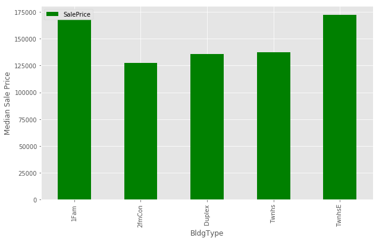

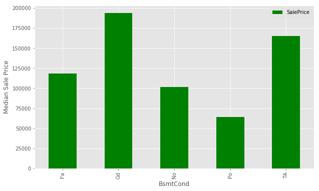

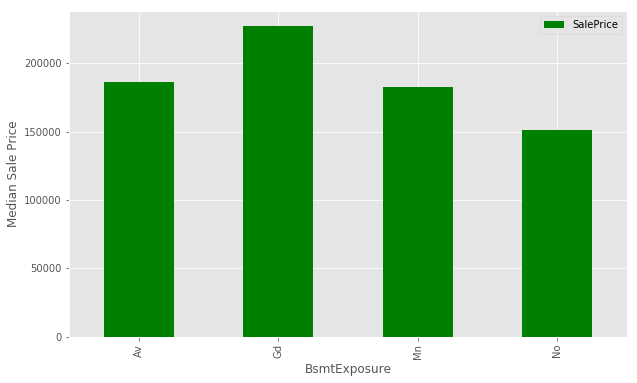

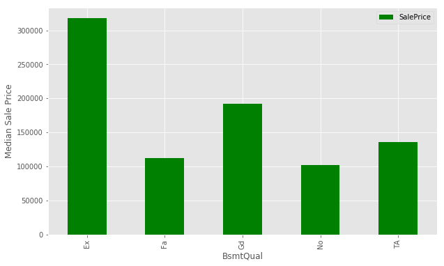

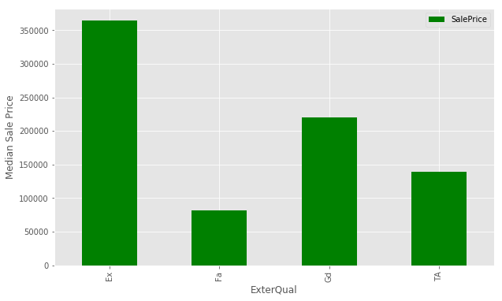

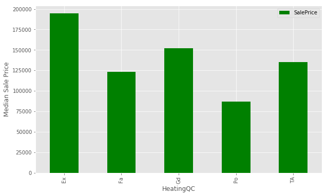

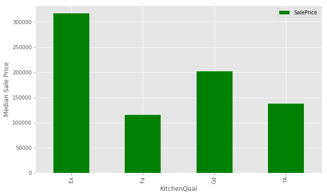

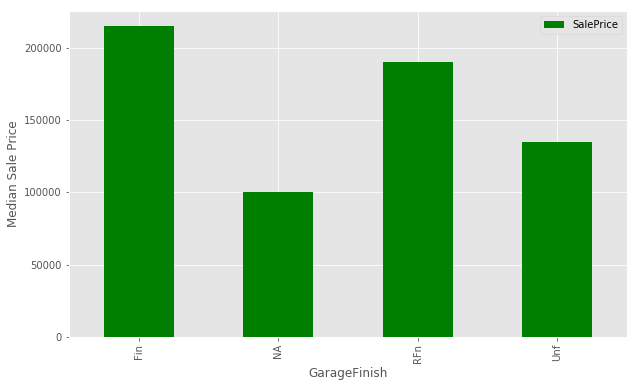

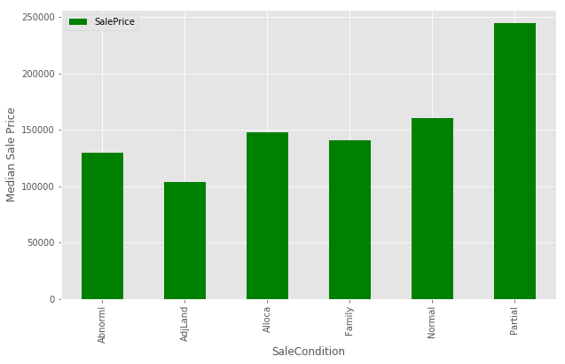

```python
def draw_pivot(x):
    plt.figure()
    cond_pivot = train_df.pivot_table(index = x, values = 'SalePrice', aggfunc = np.median)
    cond_pivot.plot(kind = 'bar', color = 'green')

    plt.xlabel(x)
    plt.ylabel('Median Sale Price')
print('''
          ..............Pivot tables before encoding.................
''')
for x in ['BldgType','BsmtCond', 'BsmtExposure', 'BsmtQual', 'ExterQual', 'HeatingQC','KitchenQual','GarageFinish','SaleCondition']:
    draw_pivot(x)
```